# Personal Activity Report

## Personal Activity Report

Data used for this report were collected from an anonymous individual during the months of October and November, 2012 using personal activity monitoring device. This device records data at 5 minute intervals through out the day for 61 days.

### Load data and initial exploratory data analysis

```r
#read in data
url="https://d396qusza40orc.cloudfront.net/repdata%2Fdata%2Factivity.zip"
download.file(url, destfile = "/Users/zhihuang/desktop/Project1/activity.zip", method="curl")
data <- read.csv(unzip("/Users/zhihuang/desktop/Project1/activity.zip"))
# convert date to Date class
data$date <- as.Date(data$date, format = "%Y-%m-%d")
str(data)
```

```
## 'data.frame':    17568 obs. of  3 variables:
##  $ steps   : int  NA NA NA NA NA NA NA NA NA NA ...
##  $ date    : Date, format: "2012-10-01" "2012-10-01" ...
##  $ interval: int  0 5 10 15 20 25 30 35 40 45 ...
```

### Extimate the mean total number of steps taken per day?

1. Make a histogram of the total number of steps taken each day
2. Calculate the mean and median total number of steps taken per day

[figure not shown]

```r
require("plyr")
data2 <- na.omit(data)
sum<- ddply(data2, .(date), summarize, sum.steps = sum(steps))
hist(sum$sum.steps, breaks=20, col="yellow", main="Frequency of Daily Steps in 61 Days",
        xlab="Steps Per Day")
```

```r
mean(sum$sum.steps)
```

```
## [1] 10766.19
```

```r
median(sum$sum.steps)
```

```
## [1] 10765
```

The mean total number of steps taken each day is 10766.19, the median is 10765.

### Average daily activity pattern

1. Make a time series plot (i.e. type = “l”) of the 5-minute interval (x-axis) and the average number of steps taken, averaged across all days (y-axis)
2. Which 5-minute interval, on average across all the days in the dataset, contains the maximum number of steps?

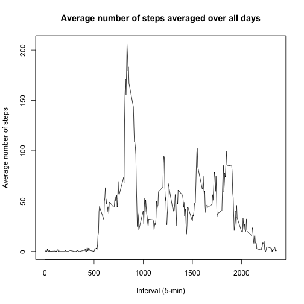

```r
mean<- ddply(data2, .(interval), summarize, mean.steps = mean(steps, na.rm = TRUE))
plot(mean$interval, mean$mean.steps, type='l', col=1,
        main="Average number of steps averaged over all days",
        xlab="Interval (5-min)", ylab="Average number of steps")
```

```r
maxsteps<- which.max(mean$mean.steps)
mean[maxsteps, ]
```

```
##     interval mean.steps
## 104      835   206.1698
```